# Untitled5_(5)

**Scatter Plot to visualize alcohol consumption and its relation with total crashes :**

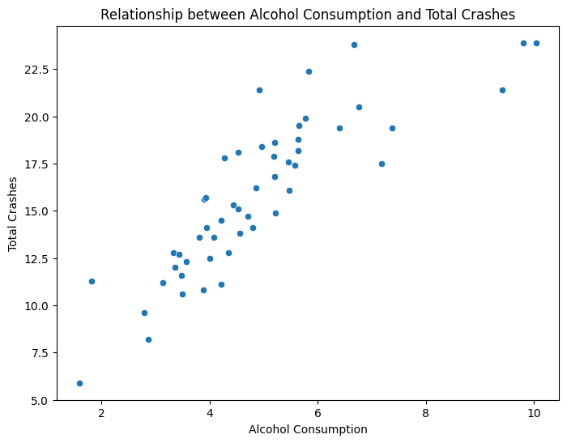

```python
plt.figure(figsize=(8, 6))
sns.scatterplot(x='alcohol', y='total', data=crashes)
plt.xlabel('Alcohol Consumption')
plt.ylabel('Total Crashes')
plt.title('Relationship between Alcohol Consumption and Total Crashes')
plt.show()
```

**Inference for Scatter Plot :**

Observing the relationship of alcohol consumption and total crashes Suggest that higher alcohol consumption is associated with more crashes.

**Regression Plot to show the linear relationship :**

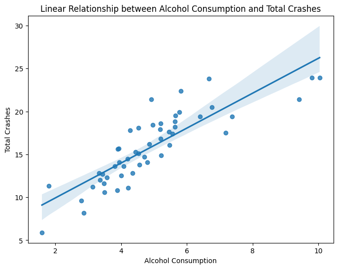

```python
plt.figure(figsize=(8, 6))
sns.regplot(x='alcohol', y='total', data=crashes)
plt.xlabel('Alcohol Consumption')
plt.ylabel('Total Crashes')
plt.title('Linear Relationship between Alcohol Consumption and Total Crashes')
plt.show()
```

**Inference for Regression Plot :**

Visualizing the linear relationship between alcohol consumption and total crashes and Highlight the positive linear correlation between them.

**Box Plot to visualize alcohol consumption :**

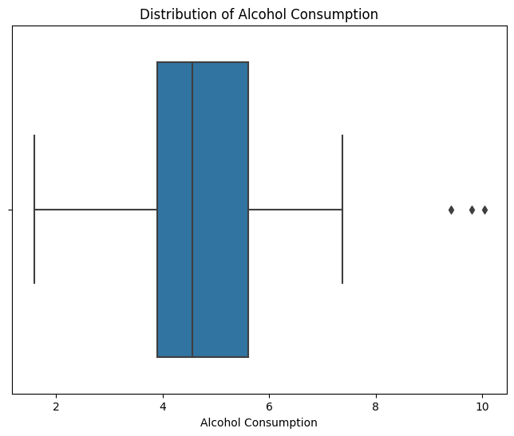

```python
plt.figure(figsize=(8, 6))
sns.boxplot(x='alcohol', data=crashes)
plt.xlabel('Alcohol Consumption')
plt.title('Distribution of Alcohol Consumption')
plt.show()
```

**Inference for Box Plot:**

Observing the distribution of alcohol consumption and including any outliers

**Histogram for visualizing the distribution of total crashes :**

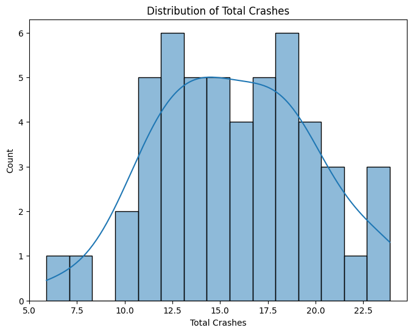

```python
plt.figure(figsize=(8, 6))
sns.histplot(crashes['total'], bins=15, kde=True)
plt.xlabel('Total Crashes')
plt.title('Distribution of Total Crashes')
plt.show()
```

**Inference for Histogram :**

Understanding the shape and the spread of the distribution of total crashes.

**Correlation Heatmap :**

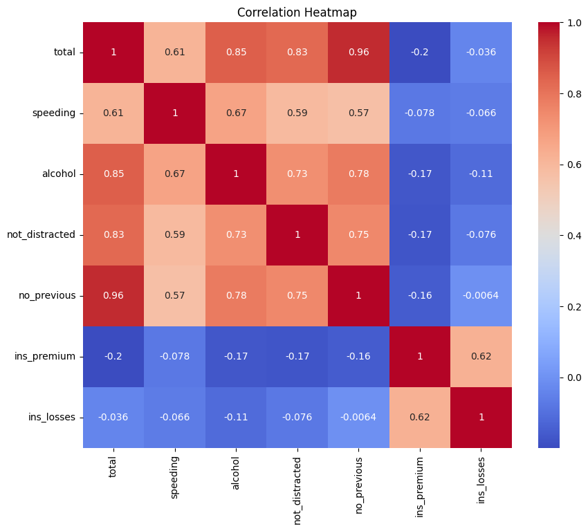

```python
correlation_matrix = crashes.corr(numeric_only=True)
plt.figure(figsize=(10, 8))
sns.heatmap(correlation_matrix, annot=True, cmap='coolwarm')
plt.title('Correlation Heatmap')
plt.show()
```

**Inference for Heatmap :**

Visualizing the correlation between different numerical variables and to Identify strong and weak correlations between variables.

# **Conclusion :**

In our analysis of car crash statistics using the "Car Crashes" dataset available in the Seaborn library, our primary objective was to extract valuable insights regarding the various factors that contribute to car accidents.